# Untitled

Gilad Ravid

11/14/2021

תרגול ב ggplot

בתרגילים אלו נשתמש בסדרות נתונים המסופקים עם חבילת ggplot2 . ניתן לראות את כל סדרות הנתונים על ידי הפקודה data(package = “ggplot2”)

```r
library(ggplot2)
library(dplyr)
```

1. כיצד תתארו את היחס בין cty ל hwy (נתוני mpg)? האם ישם בעיה בהסקת מסקנות מגרף זה? To understand the relationship, we need to make a plot:

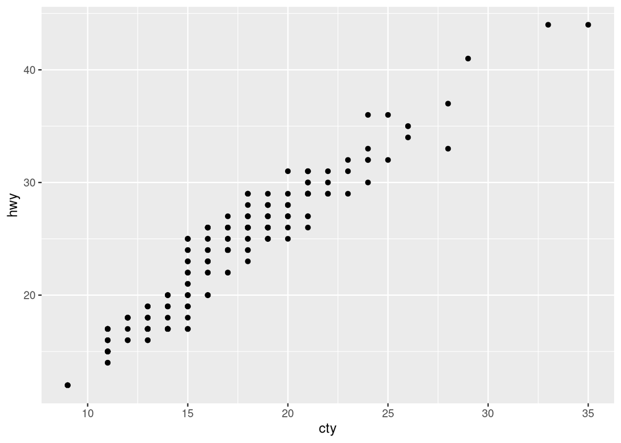

```r
ggplot(mpg, aes(x = cty, y = hwy)) +
  geom_point()
```

It appears that there is a positive linear relationship between cty and hwy.

2. מה הנתונים שהגרף ggplot(mpg, aes(model, manufacturer)) + geom point() מראה? האם זה שימושי? כיצד ניתן לשנות את הנתונים ו/או הגרף על מנת להפוך אותו לאינפורמטיבי יותר?

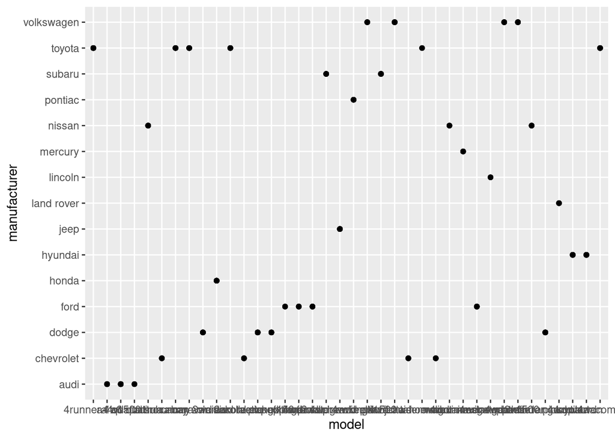

```r
ggplot(mpg, aes(model, manufacturer)) +
  geom_point()
```

This plot has problems. First, the x-axis names in model are too long, that the plot doesn’t show all the full names. This makes it impossible for people to understand. Second, this plot doesn’t really help people understand the relationship between model and manufacturer for the manufacturer may have several models such as e.g. audi and camry.

A better approach is to check a manufacturer+model combination count

```r
df <- mpg %>%
  mutate(manuModel = paste(manufacturer, model, sep = " "))

df  %>%
  select(manufacturer, model, manuModel)
```

```
## # A tibble: 234 × 3
##    manufacturer model      manuModel
##    <chr>        <chr>      <chr>
##  1 audi         a4         audi a4
##  2 audi         a4         audi a4
##  3 audi         a4         audi a4
##  4 audi         a4         audi a4
##  5 audi         a4         audi a4
##  6 audi         a4         audi a4
##  7 audi         a4         audi a4
##  8 audi         a4 quattro audi a4 quattro
##  9 audi         a4 quattro audi a4 quattro
## 10 audi         a4 quattro audi a4 quattro
## # … with 224 more rows
```

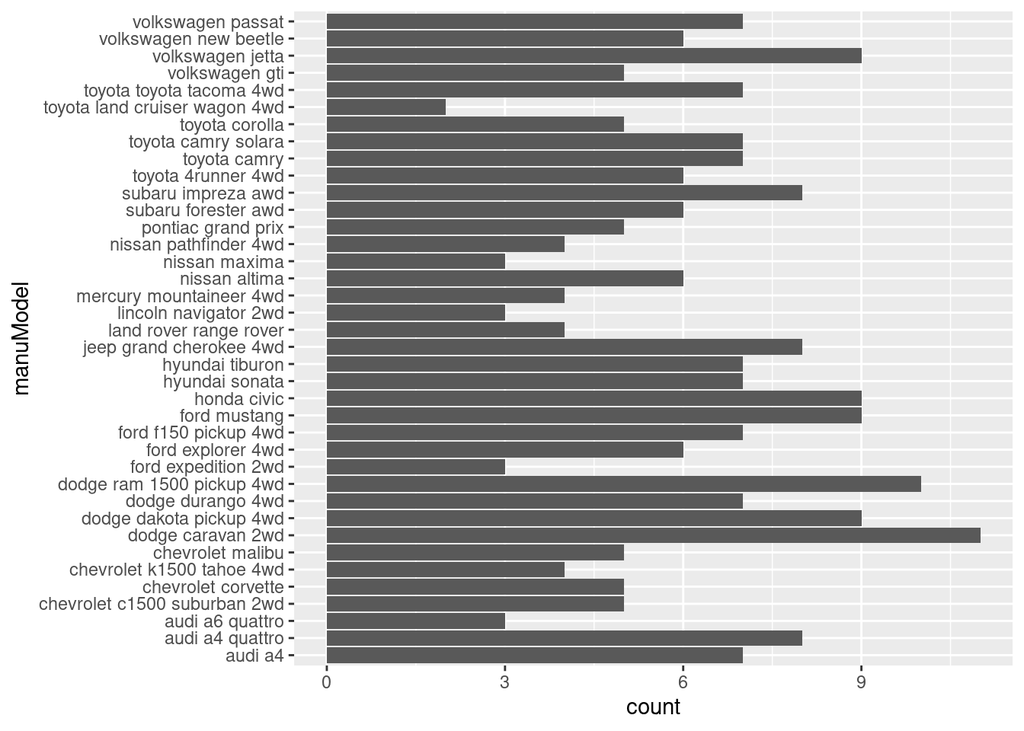

```r
ggplot(df, aes(x = manuModel)) +
  geom_bar() +
  coord_flip()
```

3. תאר את הנתונים, אסטתיקה, מיפוי ושכבות המשמשים בכל אחד מהגרפים הבאים ggplot(mpg, aes(cty, hwy)) + geom point() ggplot(diamonds, aes(carat, price)) + geom point() ggplot(economics, aes(date, unemploy)) + geom line() ggplot(mpg, aes(cty)) + geom histogram()

```r
summary(ggplot(mpg, aes(cty, hwy)) + geom_point())
```

```
## data: manufacturer, model, displ, year, cyl, trans, drv, cty, hwy, fl,
##   class [234x11]
## mapping:  x = ~cty, y = ~hwy
## faceting: <ggproto object: Class FacetNull, Facet, gg>
##     compute_layout: function
##     draw_back: function
##     draw_front: function
##     draw_labels: function
##     draw_panels: function
##     finish_data: function
##     init_scales: function
##     map_data: function
##     params: list
##     setup_data: function
##     setup_params: function
##     shrink: TRUE
##     train_scales: function
##     vars: function
##     super:  <ggproto object: Class FacetNull, Facet, gg>
## -----------------------------------
## geom_point: na.rm = FALSE
## stat_identity: na.rm = FALSE
## position_identity
```

As you can see, we can use summary() function to get full details about a chunk of plot codes. But in general, the codes above has one dataset, mapping to two variables in that data set, and has one layer of plots.

4. מה קורה כאשר ממפים משתנה רציף לאסטתיקת colour, size? ומה קורב במשתנה קטגוריאלי? מה קורה כאשר משתמשים ביותר מאסטתיקה אחת?

Using mpg dataset as an example, first I map color, shape, and size to continuous variables:

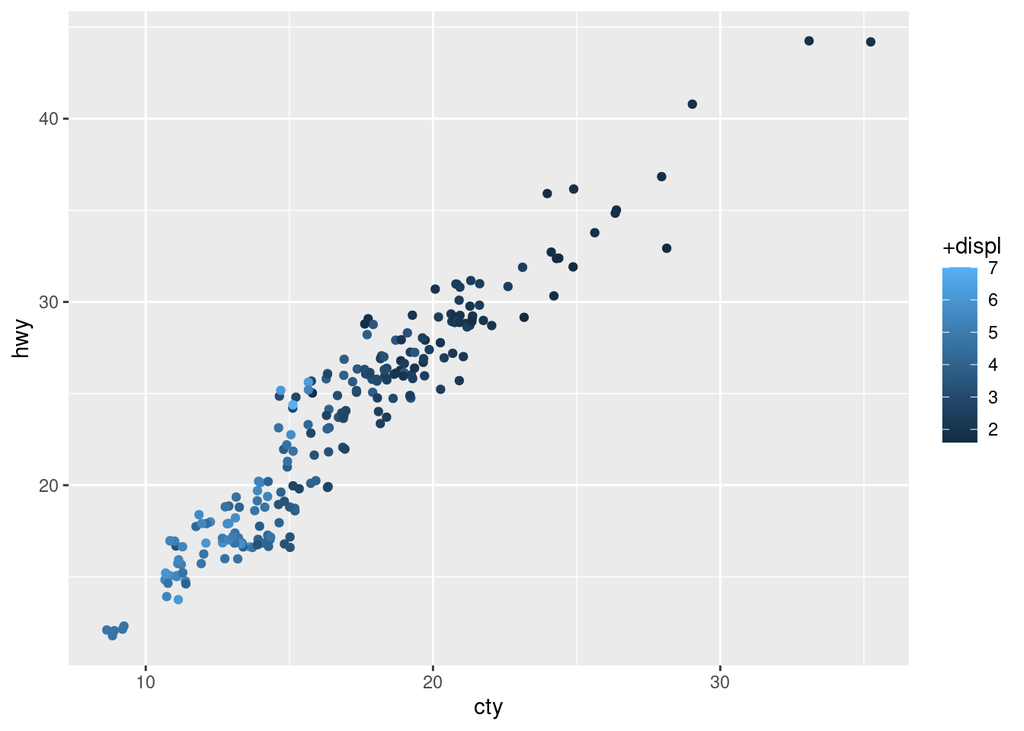

```r
ggplot(mpg, aes(cty, hwy, color = +displ)) +
  geom_jitter()
```

What you get is a color scale, which you can use +/- sign to change the direction of color scale.

But the problem is that, color and size might work with continuous variables, but shape doesn’t. Because the various numbers could deplete the current availble shapes that represent them.

```r
ggplot(mpg, aes(cty, hwy, shape = displ)) +
  geom_point()

# You get:
# Error: A continuous variable can not be mapped to shape
```

You can use more than one aesthetic in a plot, such as:

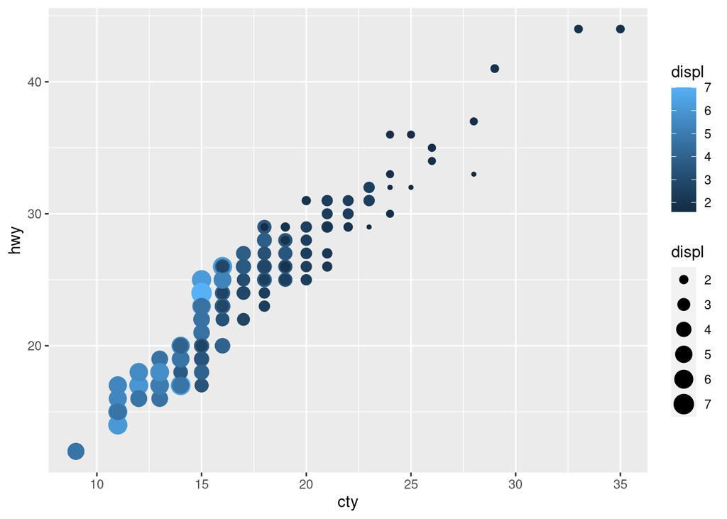

```r
ggplot(mpg, aes(cty, hwy, size = displ, color = displ)) +
  geom_point()
```

5. מה קורה כאשר ממפים משתנה רציף לצורה ? למה? מה קורה כאשר ממפים את המשתנה trans (מנתוני mpg) לצורה? למה?

The first part has been answered in the previous question. The second part to map trans to shape:

```
## Warning: The shape palette can deal with a maximum of 6 discrete values because
## more than 6 becomes difficult to discriminate; you have 10. Consider
## specifying shapes manually if you must have them.
```

```
## Warning: Removed 96 rows containing missing values (geom_point).
```

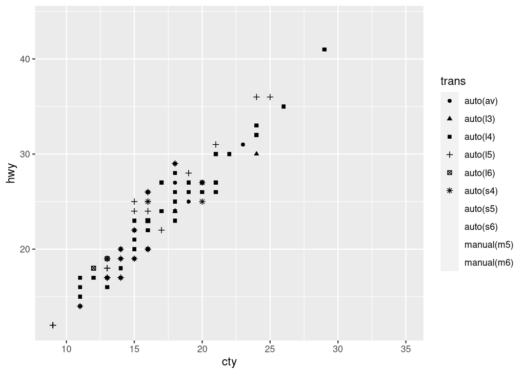

```r
ggplot(mpg, aes(cty, hwy, shape = trans)) +
  geom_point()
```

The plot generates a warning that shape for more than 6 discrete values becomes hard to discriminate.

6. כיצד הנעת הרכב (drv) קשורה לצריכת הדלק בעיר?

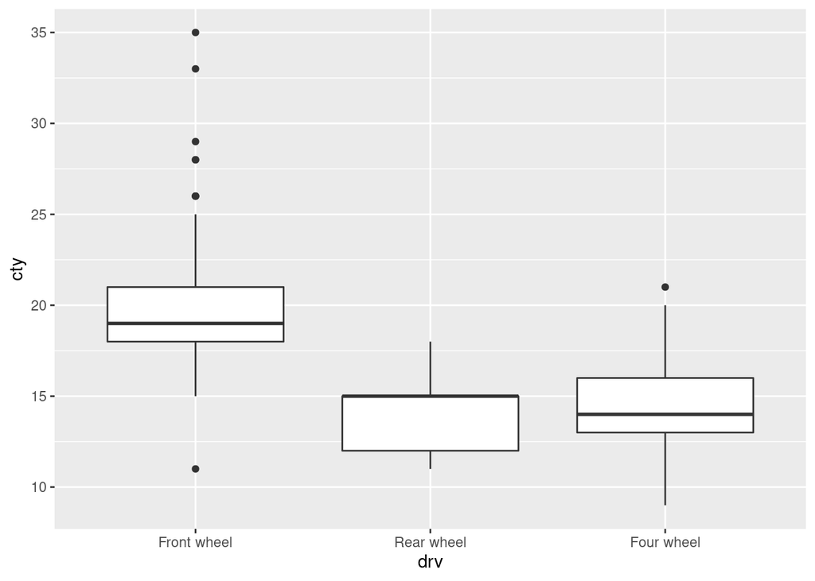

```r
ggplot(mpg, aes(drv, cty)) +
  geom_boxplot() +
  scale_x_discrete(labels = c("Front wheel", "Rear wheel", "Four wheel"),
                   limits = c("f", "r", "4"))
```

For drive train, engine size, and class, we need to reorder the class based on engine size first with median, and then plot class on x-axis and engine size on y-axis, with drive train as color.

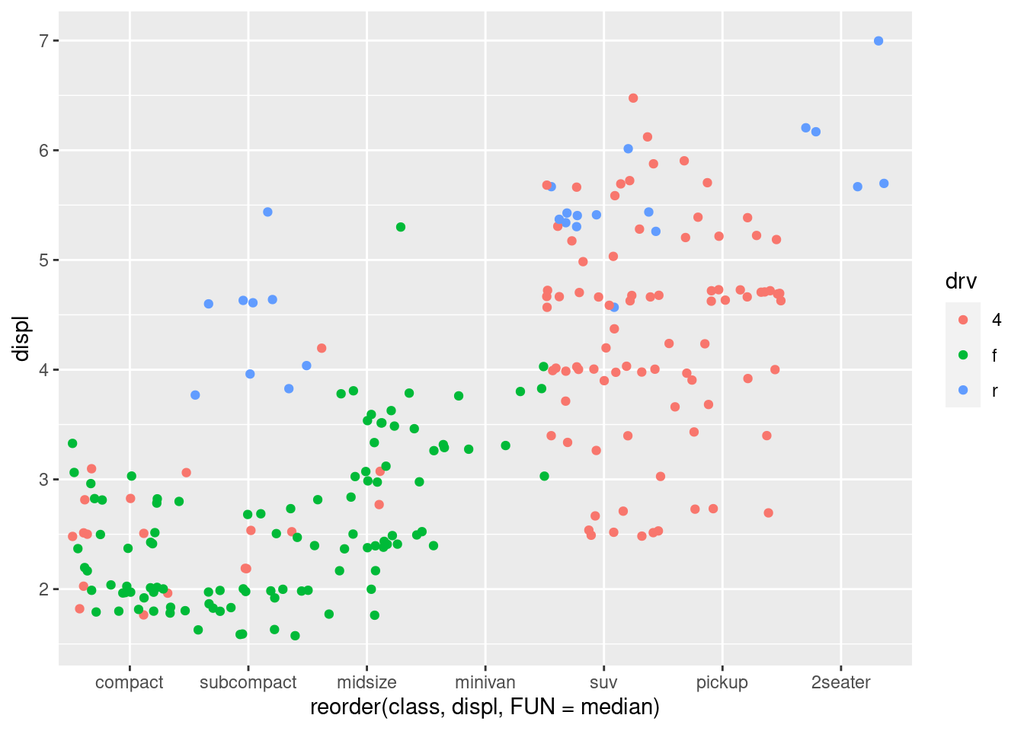

```r
ggplot(mpg, aes(reorder(class, displ, FUN = median), displ, color = drv)) +
  geom_jitter(width = 0.5)
```

8. מה קורה כאשר מיצרים לוחות (facet) למשתנה רציף כמו hwy? ומה קורה ב cyl? מה ההבדלים?

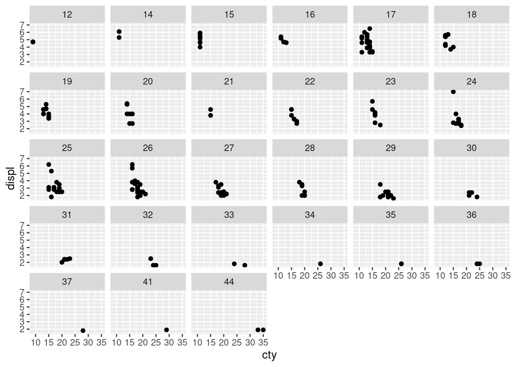

```r
ggplot(mpg, aes(x = cty, y = displ)) +
  geom_point() +
  facet_wrap(~ hwy)
```

When you run facet_wrap(~continuous) with continuous variable, the whole plot becomes hard to grasp because there are too many graphs.

Then we try to run the same thing with cyl:

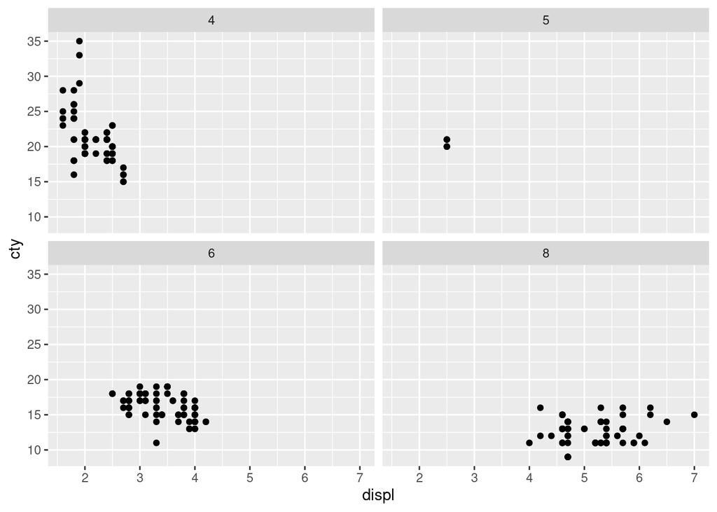

```r
ggplot(mpg, aes(displ, cty)) +
  geom_point() +
  facet_wrap(~ cyl)
```

With cyl, which only has four different values, this picture is much easier to read. The key difference is that hwy has way too many variation in values than cyl does.

9. השתמש בלוחות כדי לחקור את הקשר בין צריכת דלק, גודל מנוע, ומספר צלינדרים. כיצד השימוש בלוחות לפי מספר צלינדרים משנה את ההערכתם?

The pattern can be seen in the last plot.

10. מה הבעיה עם התרשים שנוצר על ידי ggplot(mpg, aes(cty, hwy)) + geom point() כיצד ניתן לפתור זאת?

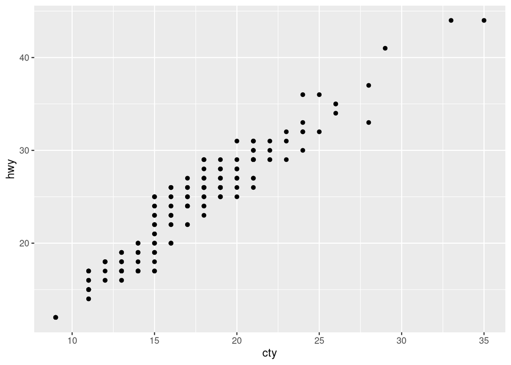

```r
ggplot(mpg, aes(cty, hwy)) +
  geom_point()
```

The problem with this plot is that, there is overplotting, so that this graph doesn’t show all the availble data points in the dataset.

The solution to this problem is to use geom_jitter().

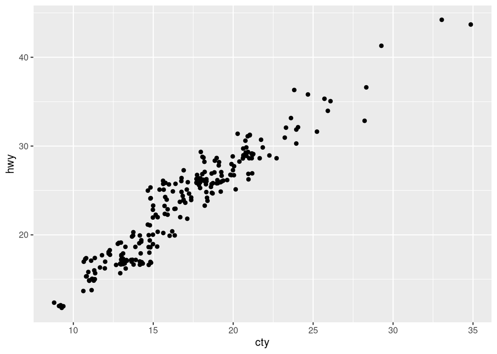

```r
ggplot(mpg, aes(cty, hwy)) +
  geom_jitter()
```

11. חקור את ההתפלגות של המשתנה carat בסט נתוני diamonds. איזה binwidth חושף את הצורה המעניינת ביותר

We can generate several plots with different binwidth:

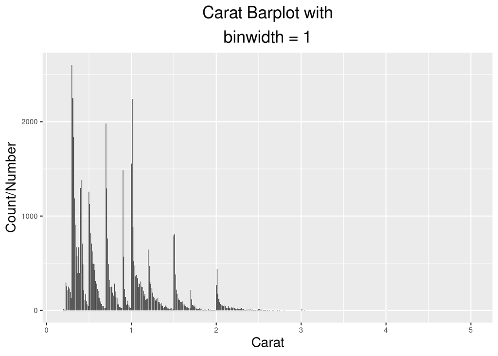

```r
ggplot(diamonds, aes(carat)) +
  geom_bar(binwidth = 1) +
  ggtitle(expression(atop("Carat Barplot with", "binwidth = 1"))) +
  xlab("Carat") +
  ylab("Count/Number") +
  theme(plot.title = element_text(hjust = 0.5), title = element_text(size = 14),
        text = element_text(size = 9))
```

As we change the binwidth:

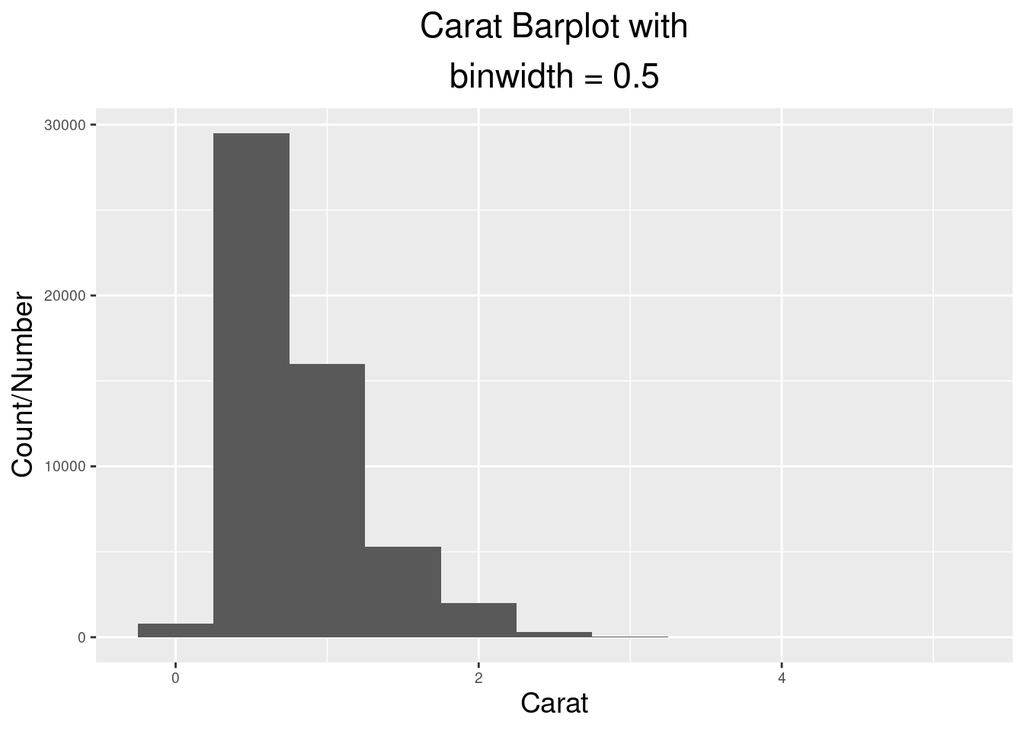

```r
ggplot(diamonds, aes(carat)) +
  geom_histogram(binwidth = 0.5) +
  ggtitle(expression(atop("Carat Barplot with", "binwidth = 0.5"))) +
  xlab("Carat") +
  ylab("Count/Number") +
  theme(plot.title = element_text(hjust = 0.5), title = element_text(size = 14),
        text = element_text(size = 9))
```

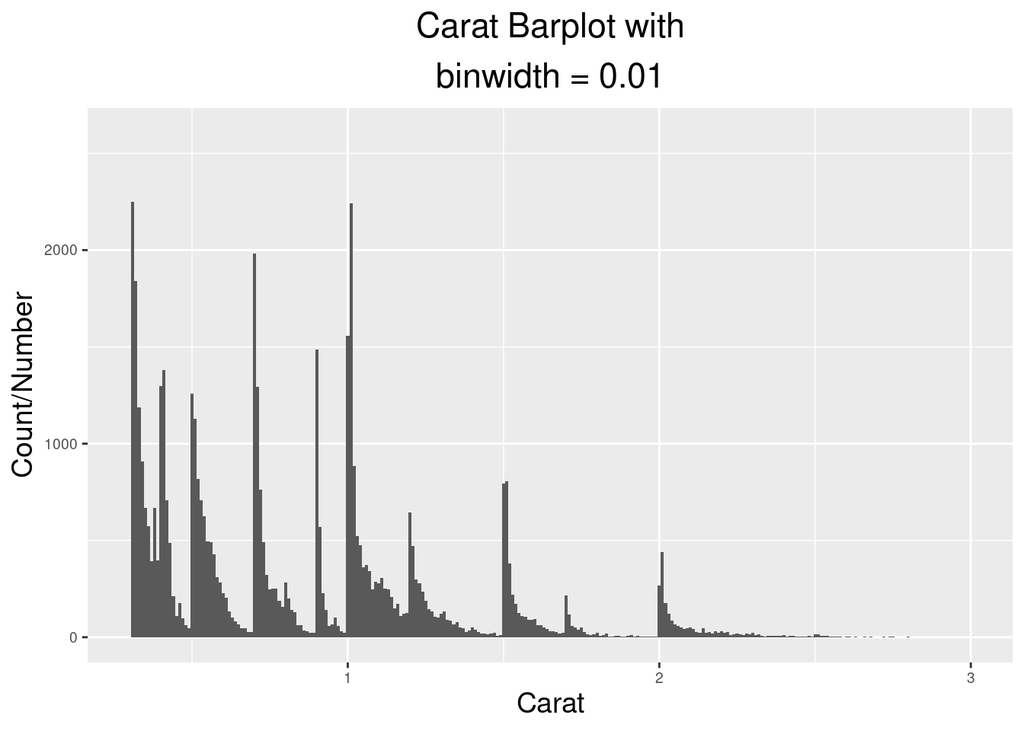

```r
ggplot(diamonds, aes(x = carat)) +
  geom_histogram(binwidth = 0.01) +
  ggtitle(expression(atop("Carat Barplot with", "binwidth = 0.01"))) +
  xlim(0.3, 3) +
  xlab("Carat") +
  ylab("Count/Number") +
  theme(plot.title = element_text(hjust = 0.5), title = element_text(size = 14),
        text = element_text(size = 9))
```

I am not familiar with diamonds industry, but the pattern looks interesting and there must be a reason for this pattern.

12. חקור את התפלגות משתנה המחיר בנתוני היהלומים. כיצד ההתפלגות משתנה לפי cut?

To check this::

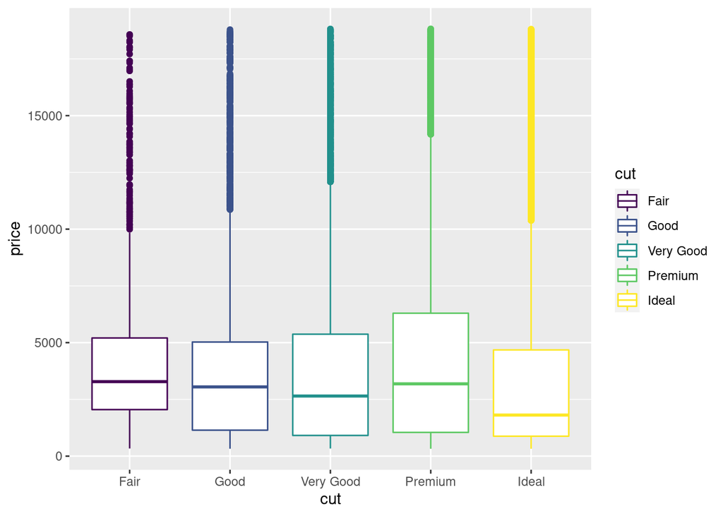

```r
ggplot(diamonds, aes(x = cut, y = price, color = cut)) +
  geom_boxplot()
```

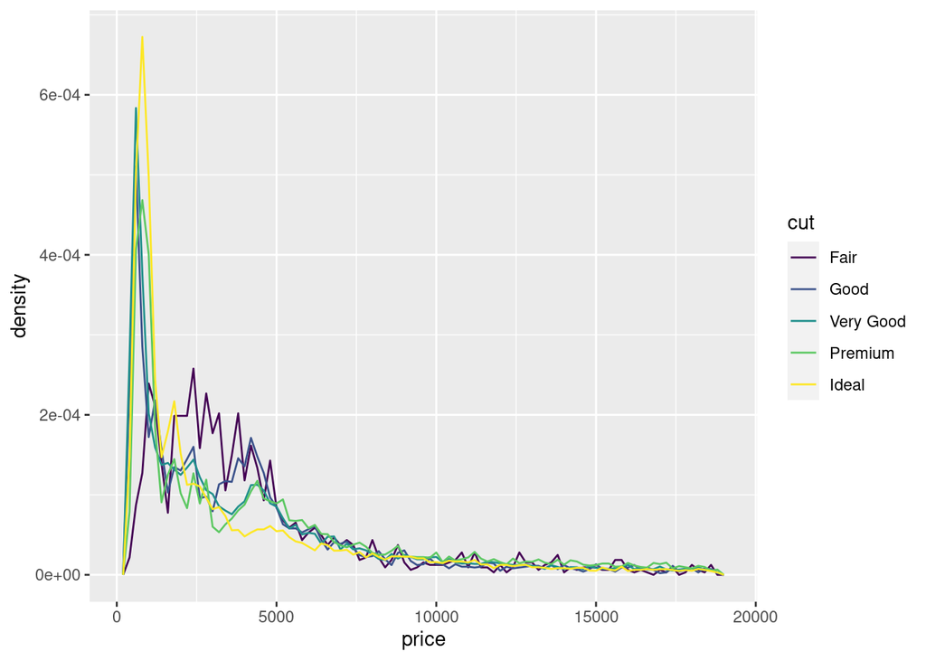

```r
ggplot(diamonds, aes(x = price, y =..density.., color = cut)) +
  geom_freqpoly(binwidth = 200)
```

Fair cut diamonds have higher price than very good cut. One of the reasons could be these fair diamonds are big in terms of their sizes, so people are likely to spend money for the size than for the cut, because not everyone is an expert in diamonds.

13. צייר בוקספלוט ל hwy לכל ערך של cyl, nckh kvpul t, בטך לפקטור. איז אסטיקה נוספת היית צריך להוסיף?

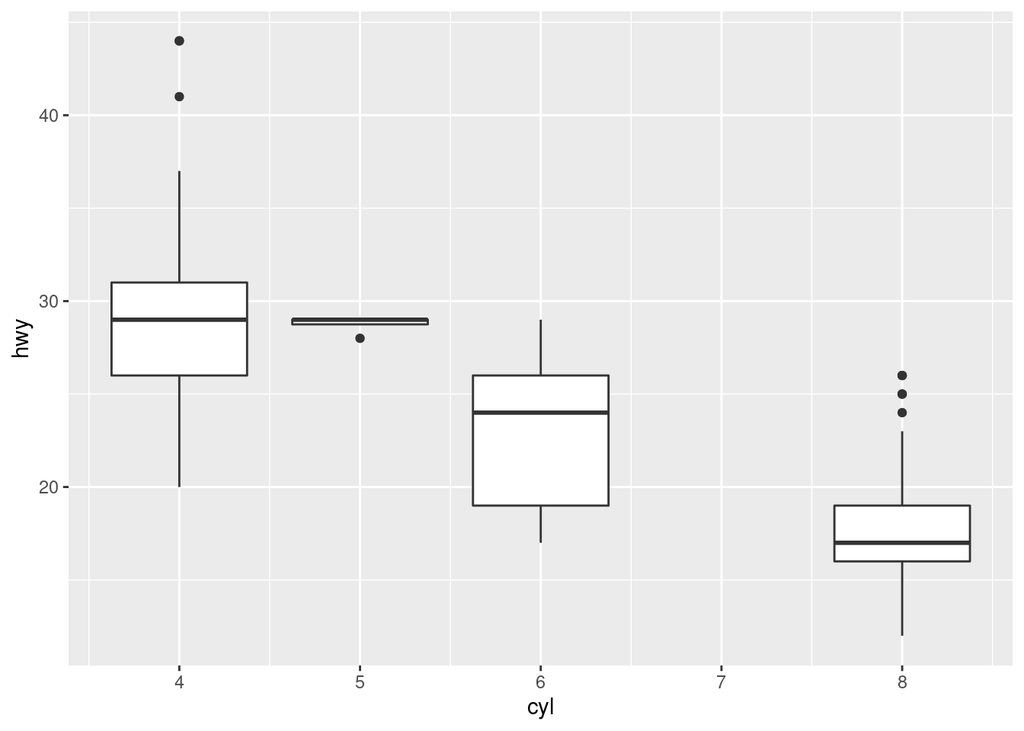

```r
ggplot(mpg, aes(cyl, hwy, group = cyl)) +
  geom_boxplot()
```

You simply add a “group = cyl” argument within the overall aes in ggplot()

14. שנה את הפקודה ggplot(mpg, aes(displ, cty)) + geom_boxplot() כך שיהיה בוקספלוט לכל ערך שלם של displ

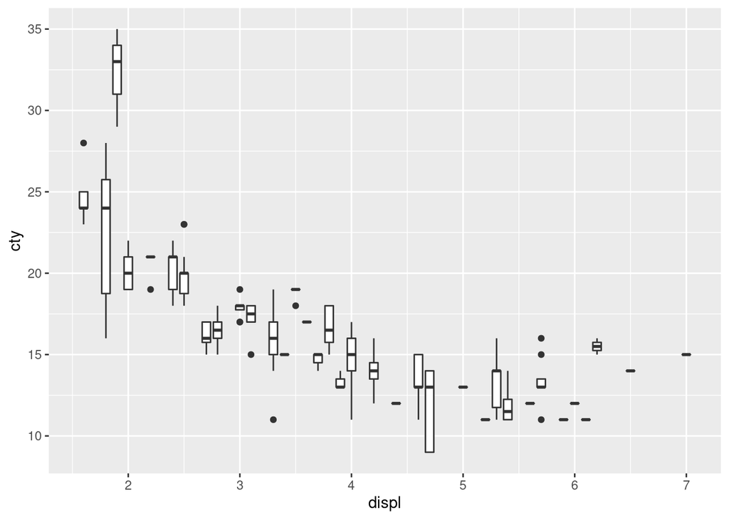

```r
ggplot(mpg, aes(displ, cty)) +
  geom_boxplot(aes(group = displ))
```

15. כמה עמודות בכל אחד מהגרפים הבאים ggplot(mpg, aes(drv)) +geom_bar() ggplot(mpg, aes(drv, fill = hwy, group = hwy)) +geom_bar() library(dplyr) mpg2 <- mpg %>% arrange(hwy) %>% mutate(id = seq_along(hwy)) ggplot(mpg2, aes(drv, fill = hwy, group = id)) +geom_bar()

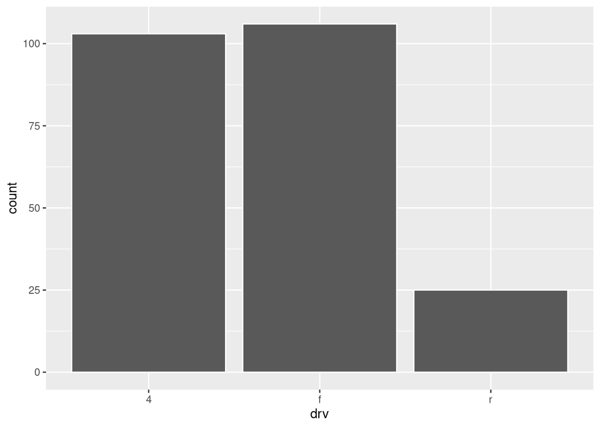

```r
ggplot(mpg, aes(drv)) + geom_bar(colour="white")
```

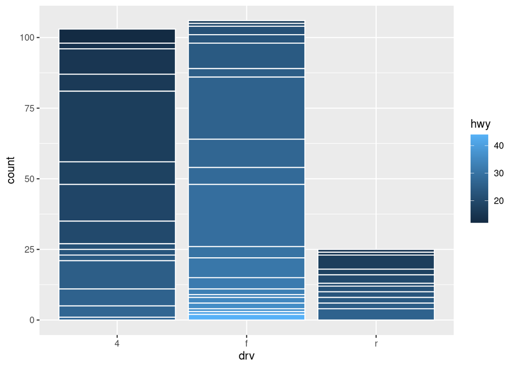

```r
ggplot(mpg, aes(drv, fill = hwy, group = hwy)) + geom_bar(colour="white")
```

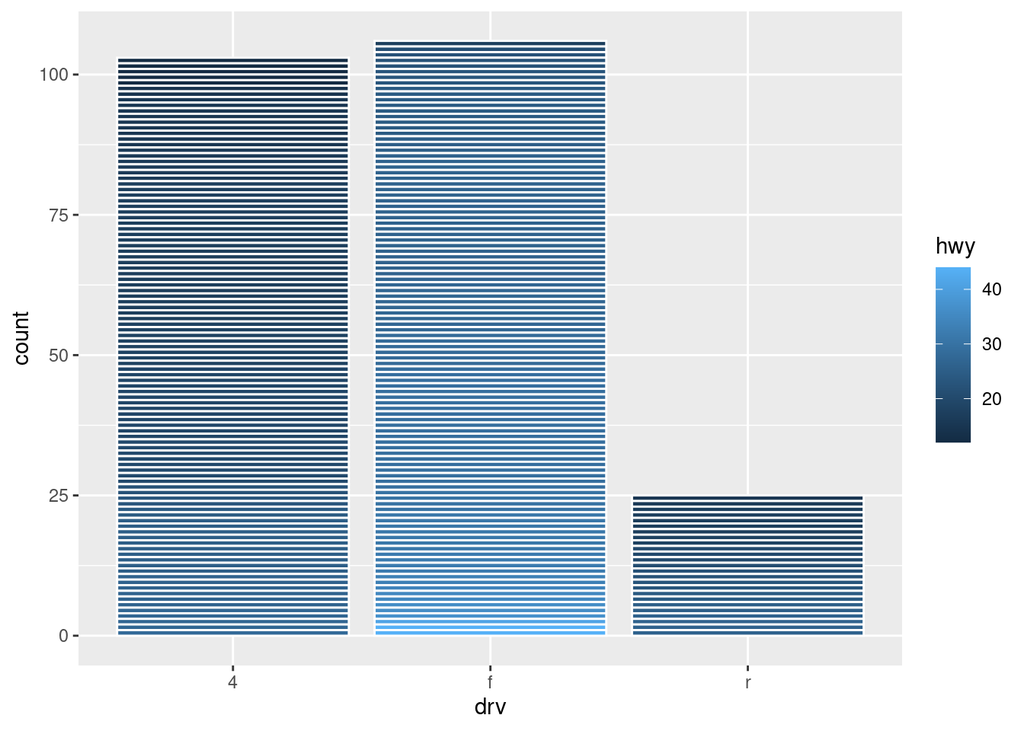

```r
library(dplyr)
mpg2 <- mpg %>% arrange(hwy) %>% mutate(id = seq_along(hwy))
ggplot(mpg2, aes(drv, fill = hwy, group = id)) + geom_bar(colour="white")
```

All have 3 bars.

16. תקן את הגרף שנוצר מהפקודות הבאות. מה הבעיה בגרף? library(babynames) hadley <- dplyr::filter(babynames, name == “Hadley”) ggplot(hadley, aes(year, n)) + geom_line()

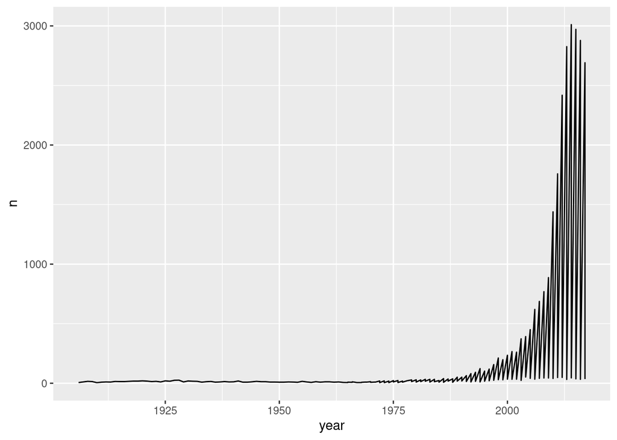

```r
library(babynames)
hadley <- dplyr::filter(babynames, name == "Hadley")
ggplot(hadley, aes(year, n)) +
geom_line()
```

We want to see the growth of the new born babies with name called “Hadley”. This graph doesn’t show the full picture, and the shape of the line is not a good representation of the number of names we want to see. In addition, if you check the data, the count is separated by sex(gender). As a result, this line plot cannot show us the full details of the name Hadley’s number’s variation across the years. Starting in 1960s, there are female babies named as “Hadley”.

```r
hadley
```

```
## # A tibble: 163 × 5
##     year sex   name       n      prop
##    <dbl> <chr> <chr>  <int>     <dbl>
##  1  1906 M     Hadley     6 0.0000416
##  2  1908 M     Hadley    16 0.0000962
##  3  1909 M     Hadley    14 0.0000792
##  4  1910 M     Hadley     5 0.0000240
##  5  1911 M     Hadley     9 0.0000373
##  6  1912 M     Hadley    11 0.0000244
##  7  1913 M     Hadley    10 0.0000186
##  8  1914 M     Hadley    15 0.0000220
##  9  1915 M     Hadley    14 0.0000159
## 10  1916 M     Hadley    14 0.0000152
## # … with 153 more rows
```

```r
male <- hadley %>%
  filter(sex == "M")
male
```

```
## # A tibble: 109 × 5
##     year sex   name       n      prop
##    <dbl> <chr> <chr>  <int>     <dbl>
##  1  1906 M     Hadley     6 0.0000416
##  2  1908 M     Hadley    16 0.0000962
##  3  1909 M     Hadley    14 0.0000792
##  4  1910 M     Hadley     5 0.0000240
##  5  1911 M     Hadley     9 0.0000373
##  6  1912 M     Hadley    11 0.0000244
##  7  1913 M     Hadley    10 0.0000186
##  8  1914 M     Hadley    15 0.0000220
##  9  1915 M     Hadley    14 0.0000159
## 10  1916 M     Hadley    14 0.0000152
## # … with 99 more rows
```

```r
female <- hadley %>%
  filter(sex == "F")
female
```

```
## # A tibble: 54 × 5
##     year sex   name       n       prop
##    <dbl> <chr> <chr>  <int>      <dbl>
##  1  1964 F     Hadley     7 0.00000358
##  2  1965 F     Hadley     6 0.00000328
##  3  1966 F     Hadley     8 0.00000456
##  4  1967 F     Hadley     6 0.0000035
##  5  1968 F     Hadley     6 0.00000351
##  6  1969 F     Hadley    10 0.00000567
##  7  1970 F     Hadley    13 0.0000071
##  8  1971 F     Hadley    10 0.00000571
##  9  1972 F     Hadley    19 0.0000118
## 10  1973 F     Hadley    20 0.0000129
## # … with 44 more rows
```

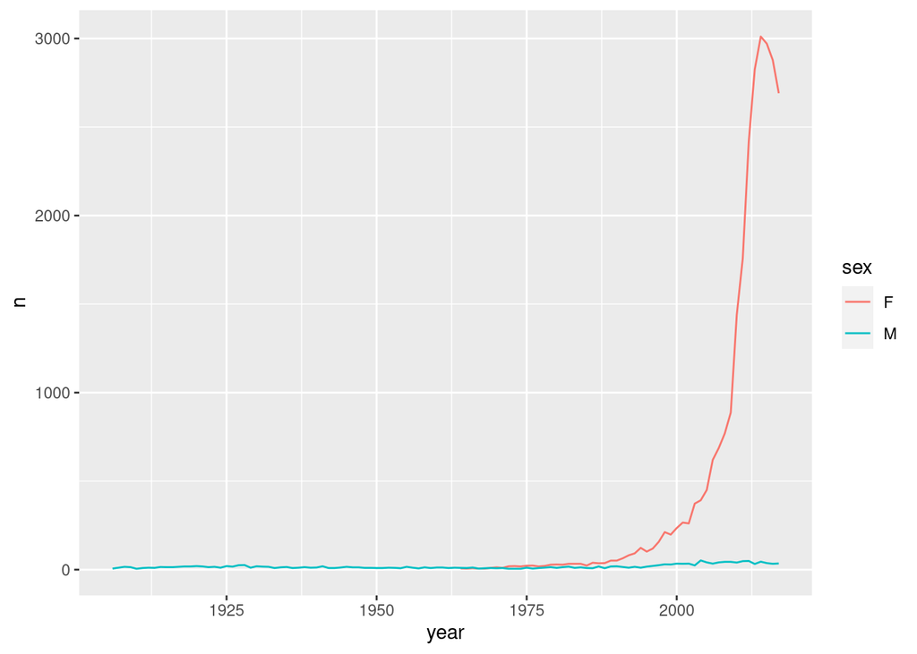

```r
ggplot(hadley) +
  geom_line(aes(year, n, color = sex))
```

17. העזר בפקודה class <- mpg %>% group_by(class) %>% summarise(n = n(), hwy = mean(hwy)) על מנת לייצר את הגרף

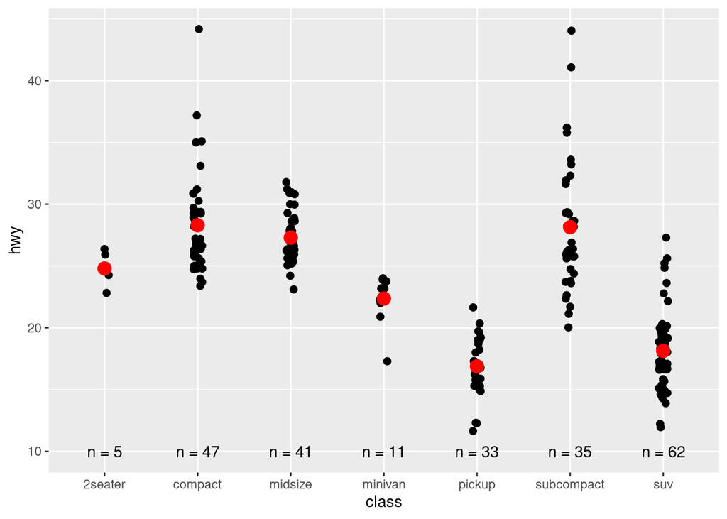

```r
class <- mpg %>% group_by(class) %>% summarise(n = n(), hwy = mean(hwy))
ggplot(mpg, aes(class, hwy))  +
  geom_jitter(width = 0.05, size = 2) +
  geom_point(aes(y = hwy), data = class, size = 4, color = "red") +
  geom_text(aes(y = 10, label = paste0("n = ", n)), data = class)
```

The process behind the scene: First, you use the ggplot() function to define the main dataset and aesthetics you want to use. Here, we want to plot the hwy(y-axis) as points against class(x-axis). This is the first line of code.